# Stationarity

Stationarity is an important concept in the field of time series analysis with tremendous influence on how the data is perceived and predicted. When forecasting or predicting the future, most time series models assume that each point is independent of one another.

## Strictly Stationary Time Series

A strictly stationary time series is one for which the probabilistic behavior of every collection of random variables

$$ \{ X_{t_1}, X_{t_2}, \cdots, X_{t_k} \} $$

is identical to that of the time shifted set

$$ \{ X_{t_1+h}, X_{t_2+h}, \cdots, X_{t_k+h} \} $$

That is,

$$ Pr(X_{t_1} \leq c_1, X_{t_2} \leq c_2, \cdots, X_{t_k} \leq c_k \}) = Pr(X_{t_1+h} \leq c_1, X_{t_2+h} \leq c_2, \cdots, X_{t_k+h} \leq c_k) $$

for all $k=1,2,\cdots$, all time points $t_1, t_2, \cdots, t_k$, all numbers $c_1, c_2, \cdots, c_k$, and all time shifts $h=0, \pm 1, \pm 2, \cdots$

### Example of Strictly Stationary Time Series

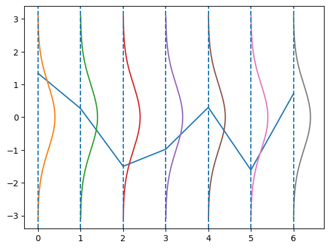

```python
ax.figure
```

## Weakly Stationary Time Series

A weakly stationary time series, $X_t$, is a process such that:

1. the mean value function, $\mu_t$, is constant and does not depend on time $t$ ,
2. the variance $\sigma_{X_t}$ is ﬁnite for all $t$, and
3. the autocovariance function, $\gamma(s, t)$, depends on $s$ and $t$ only through their difference $|s-t|$.

Henceforth, we will use the term stationary to mean weakly stationary; if a process is stationary in the strict sense, we will use the term strictly stationary.

## Autocovariance and Autocorrelation of a Stationary Time Series

The autocovariance function of a stationary time series will be written as

$$ \gamma(h) = \text{cov}(X_{t+h}, X_t) = \mathbb{E}[(X_{t+h}\mu)(X_t-\mu)] $$

The autocorrelation function of a stationary time series will be written as

$$ \rho(h) = \frac{\gamma(y+h,t)}{\sqrt{\gamma(t+h,t+h) \gamma(t,t)}}=\frac{\gamma(h)}{\gamma(0)} $$

## Stationarity of Some Statistical Models

Excersises.

Answer the following questions.

1. Is the white noise stationary?
2. Is a random walk with drift stationary?

## Trend Stationarity

A stochastic process is trend stationary if an underlying trend (function solely of time) can be removed, leaving a stationary process. Meaning, the process can be expressed as

$$ Y_t=f(t) + X_t $$

where $f(t)$ is any function $f: \mathbb{R} \rightarrow \mathbb{R}$ and $X_t$ is a stationary stochastic process with a mean of zero.

### Example of Trend Stationarity

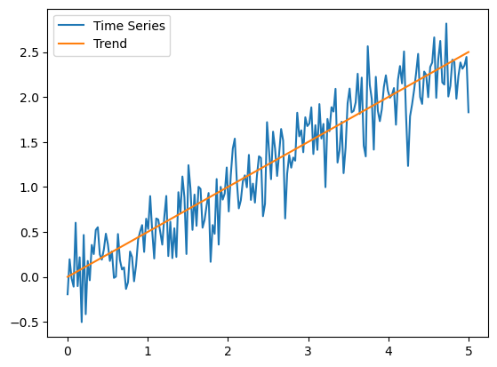

```python
ax.figure
```

## Seasonal Stationarity

A stochastic process is seasonal stationary if the joint distribution of any set of samples is invariant over a time shift of $mP$, where $m \in \mathbb{Z}$ and $P \in \mathbb{N}$ is the period of the process:

$$ Pr(X_{t_1}, \cdots, X_{t_n}) = Pr(X_{t_{1+mP}}, \cdots, X_{t_{n+mP}}) $$

### Example of Seasonal Stationarity

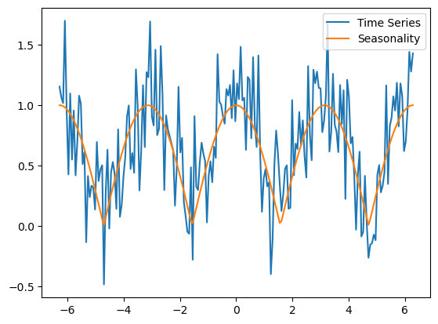

```python
ax.figure
```

## Importance of Stationarity for Estimations

Although the theoretical autocorrelation and cross-correlation functions are useful for describing the properties of certain hypothesized models, most of the analyses must be performed using sampled data.

From the point of view of classical statistics, this poses a problem because we will typically not have i.i.d. copies of $X_t$ that are available for estimating the covariance and correlation functions.

In the usual situation with only one realization, however, the assumption of stationarity becomes critical.

### Example of Stationary Time Series

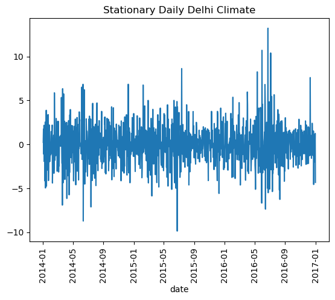

```python
ax.figure
```

## Expected Value Estimation

Sometimes we don't count with the probability distributions functions, and the only available information is a set of samples from that distribution (or a set of samples with the same mean), then to estimate te mean we will use

$$ \bar{X} = \frac{1}{N} \sum_{i=1}^{N} X_i $$

Here, $\mathbb{E}[\bar{X}]=\mu$, and the standard deviation (error) of the estimate is the square root of $\text{var}(\bar{X})$.

Why this estimation will be true even when the probability distribution isn't uniform?

### Expected Value Estimation

```
The estimated mean is -0.006729014598540146
```

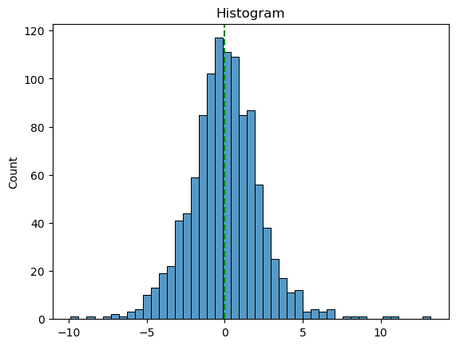

```python
print("The estimated mean is {}".format(estimated_mean))
ax.figure
```

## Variance Estimation

In many cases we need to estimate the variance from a set of samples, here we have two variants. The first of them is named *biased variance*, and it is computed as:

$$ s^2(X)=\frac{1}{N}\sum_{i=1}^{N}(X_i-\bar{X})^2 $$

and the second one is named *unbiased variance*, computed as:

$$ s^2(X)=\frac{1}{N-1}\sum_{i=1}^{N}(X_i-\bar{X})^2 $$

### Biased Variance

The bias of the first definition is caused because

$$ \mathbb{E}[s^2]=\mathbb{E}\left[\frac{1}{N}\sum_{i=1}^{N}(X_i-\bar{X})^2\right] =\frac{1}{N} \sum_{i=1}^{N} \mathbb{E}\left[ \left(X_i-\bar{X}\right)^2 \right] \\ =\frac{1}{N} \sum_{i=1}^{N} \left(\mathbb{E}[ X_i^2 ]-\mathbb{E}[\bar{X}^2]\right) =\frac{1}{N} \left( \sum_{i=1}^{N} \mathbb{E}[ X_i^2 ]- N\mathbb{E}[\bar{X}^2] \right) \\ =\frac{1}{N} \left( N \mathbb{E}[ X_1^2 ]- N\mathbb{E}[\bar{X}^2] \right) =\mathbb{E}[ X_1^2 ] - \mathbb{E}[\bar{X}^2] \\ =(\mathbb{E}[ X_1^2 ] - \mathbb{E}[ X_1 ]^2 ) + \mathbb{E}[ X_1 ]^2 - (\mathbb{E}[\bar{X}^2] - \mathbb{E}[\bar{X}]^2) - \mathbb{E}[\bar{X}]^2 \\ = \text{var}(X_1) + \mu^2 - \text{var}(\bar{X}) - \mu^2 = \text{var}(X_1) - \frac{1}{N}\text{var}(X_1) \\ = \frac{N-1}{N}\text{var}(X_1) = \frac{N-1}{N}\sigma^2 $$

## Sample Autocovariance Function

The sample autocovariance function is deﬁned as:

$$ \hat{\gamma}(h)=\frac{1}{N}\sum_{t=1}^{N-h}(X_{t+h}-\bar{X})(X_t-\bar{X}) $$

with $\hat{\gamma}(h)=\hat{\gamma}(-h)$ for $h=0,1,\cdots,N-1$.

As in variance, this is a bias estimation, the unbiased one is divided by $N-h-1$. Another estimation could be divided by $N-h$. The advantage of the estimation described above is that it is a non-negative definite function.

The autocovariance function, $\gamma(h)$, of a stationary process is non-negative definite ensuring that variances of linear combinations of the variates $X_t$ will be never negative, then, it estimate shouldn't be negative either.

### Example of Sampled Autocovariance

```python
autocovs = np.array([autocovariance(time_series, h) for h in range(20)])
print("The estimated autocovariances are {}".format(np.round(autocovs[:3], 4)))
print("The estimated variance is {:.4f}".format(np.std(time_series) ** 2))
```

```
The estimated autocovariances are [ 5.3004 -0.6957 -0.4247]
The estimated variance is 5.3004
```

## Sampled Autocorrelation Function

The sample autocorrelation function is deﬁned as:

$$ \hat{\rho}(h)=\frac{\hat{\gamma}(h)}{\hat{\gamma}(0)} $$

### Large-Sample Distribution of the ACF

Under general conditions*, if $X_t$ is white noise, then for $n$ large, the sample ACF, $\hat{\rho}_X(h)$, for $h=1,2,\cdots,H$, where H is ﬁxed but arbitrary, is approximately normally distributed with zero mean and standard deviation given by:

$$ \sigma_{\hat{\rho}_X} = \frac{1}{\sqrt{N}} $$

Based on the previous result, we obtain a rough method of assessing if peaks in $\hat{\rho}{h}$ are signiﬁcant by determining if they are out of the interval $\pm 2\sigma_{\hat{\rho}_X}$.

The applications of this property develop because many statistical modeling procedures depend on reducing a time series to a white noise series using various kinds of transformations.

### The Correlogram

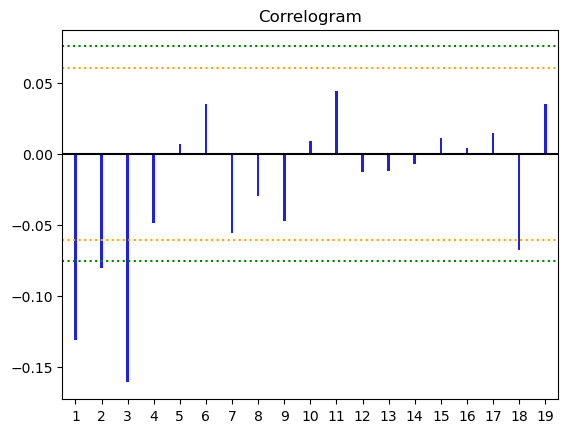

```python
ax.figure
```

## Cross-functions Estimations

The estimator for the cross-covariance function, $\gamma_{XY}(h)$ is given by

$$ \hat{\gamma}_{XY}(h) = \frac{1}{N}\sum_{t=1}^{N-h}(X_{t+h}-\bar{X})(Y_t-\bar{Y}) $$

and the estimator for the cross-correlation, $\rho_{XY}(h)$ is given by

$$ \hat{\rho}_{XY}(h)=\frac{\hat{\gamma}_{XY}(h)}{\sqrt{\hat{\gamma}_X(0) \hat{\gamma}_Y(0)}} $$

### Large-Sample Distribution of Cross-Correlation

The large sample distribution of $\hat{\rho}_{XY}(h)$ is normal with mean zero and

$$ \sigma_{\hat{\rho}_{XY}} = \frac{1}{\sqrt{N}} $$

if at least one of the processes is independent white noise.